Program Akselerasi Akademik

# FAST TRACK

Raih gelar **S1 Statistika/Ilmu Aktuaria dan S2 Statistika Terapan** dalam waktu sekitar **4,5 tahun atau 9 semester**.

Lihat Persyaratan [Hubungi via WhatsApp](https://wa.me/628180919977?text=Saya%20ingin%20berkonsultasi%20tentang%20Program%20Fast%20Track%20S1%E2%80%93S2%20Statistika%20Terapan%20Unpad.)

**9**semester untuk dua gelar

**3,00**IPK minimum

**500**minimum TKA & TKBI

**Rp13,5 Juta**UKT dibayar satu kali pada Semester 3

[figure not shown]

“

Gabung dalam Program Fast Track dan raih double gelar S1 & S2 hanya dalam 9 semester.

Persyaratan Pendaftaran

## Siapkan empat persyaratan utama.

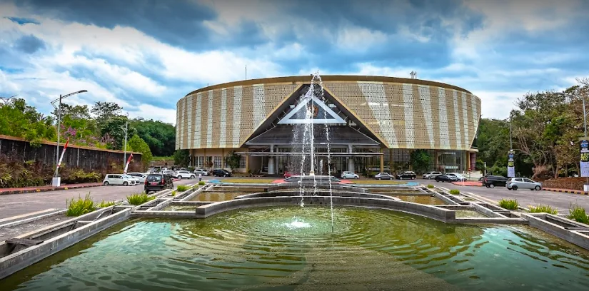

01

### Status Mahasiswa

Mahasiswa S1 Statistika atau Ilmu Aktuaria yang sedang menempuh Semester 6.

02

### IPK Minimum 3,00

Memiliki IPK sekurang-kurangnya 3,00 dan telah lulus minimal 120 SKS.

03

### Rekomendasi Akademik

Memperoleh rekomendasi dari calon pembimbing S1 dan calon pembimbing S2.

04

### TKA & TKBI Minimum 500

Skor TKA dan TKBI masing-masing sekurang-kurangnya 500.

Mengapa Fast Track?

## Lebih cepat, efisien, dan terarah.

Program dirancang agar mahasiswa unggul dapat memulai pendidikan magister sejak semester akhir jenjang sarjana.

### Keunggulan Program

- ✓Program S1 dan S2 dapat diselesaikan dalam sekitar 4,5 tahun. Mahasiswa S1 Semester 7 dapat langsung mengambil mata kuliah Magister Statistika Terapan.
- ✓Cukup membayar UKT S2 satu kali, yaitu pada Semester 3, sebesar Rp13.500.000.
- ✓Didampingi dosen profesional dan berpengalaman dalam studi, riset, publikasi, serta pengembangan karier.
- ✓Peluang kolaborasi akademik yang luas dengan jejaring nasional dan internasional.

[figure not shown]

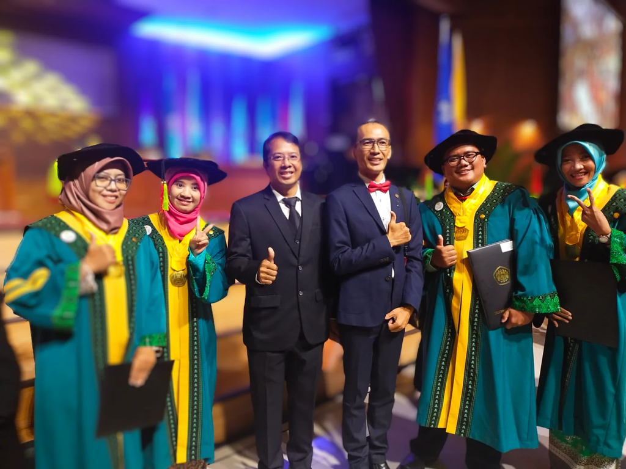

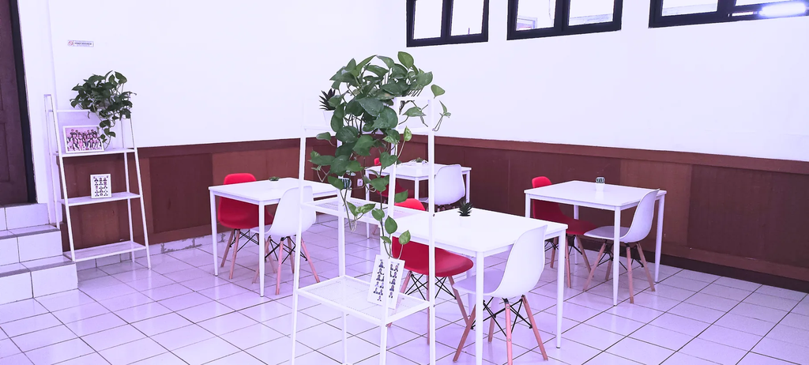

Pilihan Bidang

## Temukan konsentrasi terbaik untuk Anda.

Pembelajaran mengintegrasikan teori, komputasi, analisis data, dan penerapan statistika pada berbagai sektor.

DS

### Sains Data

Mengintegrasikan statistika, machine learning, dan pemrosesan data untuk menggali wawasan dari data besar dan kompleks.

BI

### Statistika Bisnis & Industri

Analisis data, pengambilan keputusan, dan optimalisasi proses dalam dunia bisnis dan manufaktur.

SS

### Statistika Sosial

Metode statistik untuk menganalisis data sosial, mengukur fenomena masyarakat, dan mendukung kebijakan berbasis data.

SA

### Statistika Aktuaria

Teori probabilitas dan statistika untuk mengelola risiko dan perencanaan keuangan di bidang asuransi, investasi, dan pensiun.

BIO

### Biostatistika

Metode statistik dalam penelitian biologi, kesehatan, dan medis untuk menganalisis data klinis, epidemiologi, serta pengambilan keputusan berbasis bukti.

Lingkungan Akademik

## Dosen profesional, komunitas suportif.

Kami mendukung mahasiswa untuk tumbuh melalui pembelajaran berkualitas, pembimbingan intensif, dan atmosfer akademik yang kolaboratif.

[figure not shown]

### Komunitas Akademik

Lingkungan belajar yang dekat, kolaboratif, dan berorientasi pada pengembangan kompetensi mahasiswa.

[figure not shown]

### Pengalaman Mahasiswa

Mahasiswa memperoleh dukungan akademik dan jejaring yang relevan untuk studi serta karier profesional.

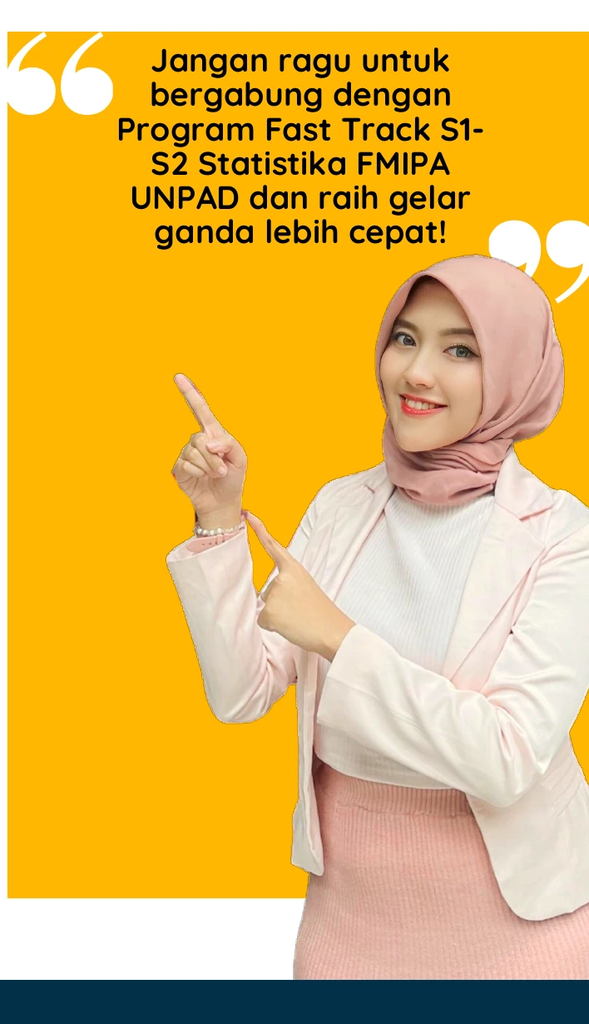

## Siap mempercepat perjalanan akademik Anda?

Konsultasikan kelayakan dan proses pendaftaran Program Fast Track S1–S2 Statistika Terapan FMIPA Universitas Padjadjaran.

[◎ @master_stat_unpad](https://instagram.com/master_stat_unpad) [◉ WhatsApp 0818 0919 977](https://wa.me/628180919977?text=Saya%20ingin%20berkonsultasi%20tentang%20Program%20Fast%20Track%20S1%E2%80%93S2%20Statistika%20Terapan%20Unpad.) ✉ kaprodi.statistikaterapan.s2@unpad.ac.id